# Coursework Report

*N* removed NAs: 2

*N* removed typo: 1

*N* removed <18: 27

*N* total clean: 120

| Group | *N* | *M*<sub>age</sub> | *M*<sub>rating</sub> |
| --- | --- | --- | --- |
| Control | 66 | 21.14 | 5.85 |
| Experim | 54 | 21.06 | 6.59 |

**Main analysis results**

*t*(118) = -5.1, *p* < .001

[interactive chart not shown]

[figure not shown]

[interactive chart not shown]

# Coursework Report

Analysing Data, Spring 2020

# Methods

## Participants

Table 1 *Descriptive statistics by condition*

| group | *N* | *M*<sub>age</sub> | *SD*<sub>Age</sub> |
| --- | --- | --- | --- |
| white | 58 | 21.55 | 2.12 |
| red | 50 | 21.30 | 2.05 |

## Design

# Results

Participants’ ratings of perceived attractiveness were analysed by condition, whether red or white. Table 2 shows means and standard deviation were very similar between the two conditions showing that the red effect was only minimal however women did always rate men slightly more attractive in the red condition than the white condition.

*Table 2* Summary of mean and standard deviation by question and condition

| group | *M*<sub>question_1</sub> | *SD*<sub>question_1</sub> | *M*<sub>question_2</sub> | *SD*<sub>question_2</sub> | *M*<sub>question_3</sub> | *SD*<sub>question_3</sub> |
| --- | --- | --- | --- | --- | --- | --- |
| white | 5.86 | 1.16 | 5.90 | 1.39 | 5.88 | 1.13 |
| red | 6.62 | 1.35 | 6.38 | 1.47 | 6.86 | 1.53 |

After further looking at our data we created a composite score which is the mean of each persons score on the three questions which suggest degree of perceives attractiveness. As all the items were measure on a 9 point scale we could then find the mean score of perceived attractiveness for the white and red group and see a pattern of the most given ratings. From the bar graph below we can see that most participants gave a rating between 5-7 which is further shown in the plotted graph suggesting that mean attractiveness scores were mostly average. The plot also shows that there was not a major difference between ratings of mean attractiveness in the red group compared with the white group however the red groups mean attractiveness ratings were slightly higher.

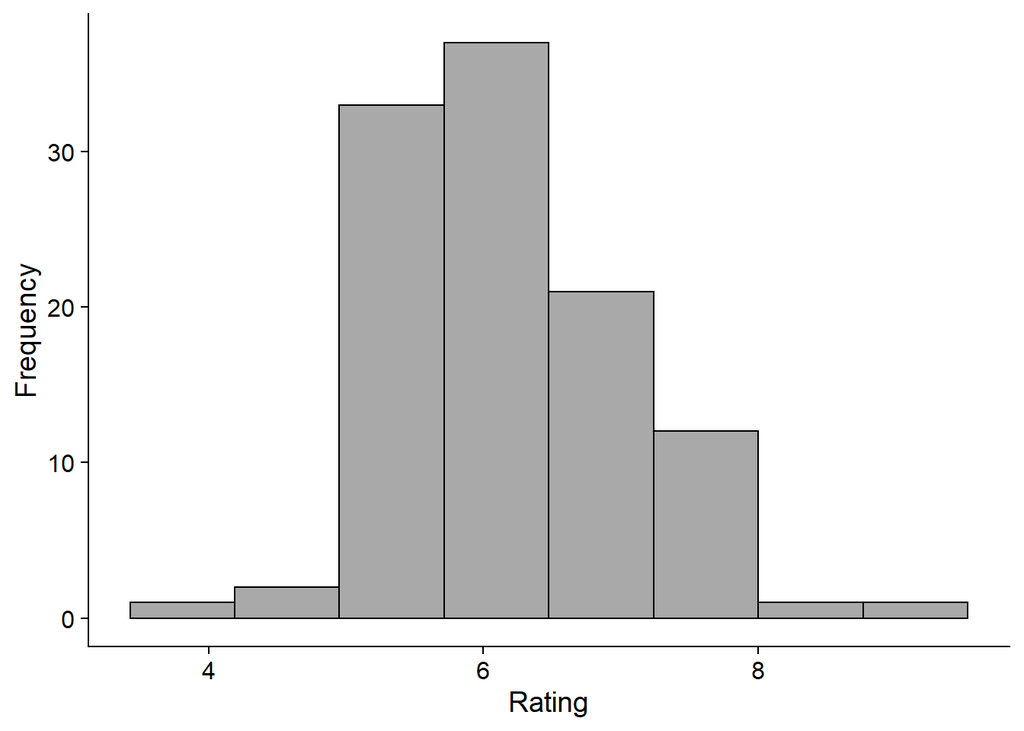

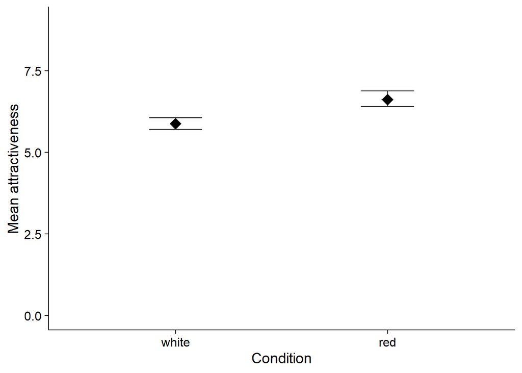

Therefore, after investigating whether the red group perceived men to be more attractive than the white group we can see the next effect. The red group gave an average score of perceived attractiveness of 6.62 whilst the white group gave an average score of 5.88. This difference although it seemed small was significant (*M*<sub>diff</sub> = -0.74 , 95% CI [-1.04,-0.44], *t* (106) = -4.84 , *p* = .000004) and therefore the sample provides enough evidence to accept the alternative hypothesis for the entire population that there is a red effect on attractiveness.

# Discussion

The experiment provided further evidence for the red effect on perceived attractiveness. There is a difference in perceived attractiveness between women who saw the man in the presence of the colour red than the colour white with a higher rating of attractiveness for the red group. This further supports the original study (Elliot et al, 2010) in which they have found a significant effect of the colour red in all seven experiments conducted. The data from this experiment further shows that women will rate a man as slightly more attractive if seen in conjunction with the colour red than the colour white which shows further support that women relate the colour red with physical attractiveness.

Many previous studies look at how the colour red is associated with perceived attractiveness and what that means in terms of love and romance. The red effect is shown in a study by Gueguen (2011) looking at men’s attraction behaviour when they see a woman in red clothing which causes men to evaluate higher sexual intent in the red condition than in the control group. This is further supported by Beall et al (2013) which shows that women are more likely to wear the colour red when they are at high risk of conception as they feel they will gain a conceiving advantage to other women. This study looked at whether the opposite is also true and if therefore men are more likely to gain a mating advantage if they are wearing the colour red. The colour red is associated with power and status and this is also shown in animals as they show a preference for mating with a male con specifics that shows the colour red; naturally or artificially as red conveys a sexual signal (Elliot et al, 2010)

Some studies suggest that there is insignificant difference for the red effect on attractiveness as males show no preference for a woman wearing red compared to a white or black dress. (Peperkoorn et al. 2016) Therefore, it would be interesting to further investigate this phenomenon and also see whether there is also a long term effect of the red effect by conducting an experiment where participants get to see a photo for 5s, complete an unrelated task and then complete the rating scales and see if the time gap has caused a decrease in the red effect shown in this experiment.

There are some limitations that should be considered in this study such as the sample size as 108 participants is not a big enough sample size to determine that the red effect is real. However, the results gained were significant which means that there might be some effect of red on men’s perceived attractiveness.

To conclude there is a suggestive link between red and attractiveness as women perceived men to be more attractive even when red is seen in the background of a photo of them. This is probably because of the link that humans make between red and power and how this then leads to a mating advantage. (Elliot et al, 2010) Further research should look at whether this effect is maintained in the long term and also use a bigger population size to increase ecological validity.

# References

Beall A. T. et al. (2013) Women Are More Likely to Wear Red or Pink at Peak Fertility Association for psychological science. 24(9) pg.1837 –1841 DOI: 10.1177/0956797613476045

Elliot, A. J., Kayser, D. N., Greitemeyer, T., Lichtenfeld, S., Gramzow, R. H., Maier, M. A., & Liu, H. (2010). Red, rank, and romance in women viewing men. Journal of Experimental Psychology: General, 139(3), 399–417.

Gueguen N. (2011) Color and Women Attractiveness: When Red Clothed Women Are Perceived to Have More Intense Sexual Intent The journal of Social Psychology, Vol.152 issue 3

Peperkoorn, L. S., Roberts, S. C., & Pollet, T. V. (2016). Revisiting the red effect on attractiveness and sexual receptivity: No effect of the color red on human mate preferences. Evolutionary Psychology, 14(4), 1–13.